# Generating AFT-Based Data with `generate_aft_dgm_flex()`

Walkthrough of the GBSG-Anchored DGM, with Emphasis on the Censoring Model

Author

Larry F. León

Published

May 6, 2026

# 1 Introduction

`generate_aft_dgm_flex()` builds an accelerated failure time (AFT) data generating mechanism (DGM) anchored on a user-supplied dataset, with flexible specification of (a) the **outcome model**, (b) **subgroup** structure, and (c) the **censoring model**. The resulting object can be passed directly to `simulate_from_dgm()` to produce simulated trials.

This vignette walks through the full function with **special emphasis on the censoring API**, which is the part most relevant when calibrating realistic simulation studies. All examples use the GBSG breast cancer dataset shipped with the `survival` package.

## 1.1 Why a separate vignette on censoring

The censoring model in the DGM is often the part that gets misconfigured in simulation studies — usually because the function exposes more flexibility than is immediately obvious. Three points worth knowing up front:

1. The censoring covariates are **specified separately** from the outcome covariates, via `continuous_vars_cens` and `factor_vars_cens`.
2. When `select_censoring = TRUE` (the default), AIC-based **model selection** chooses the best censoring distribution among four candidates — Weibull and lognormal, each with and without covariates.
3. When `select_censoring = FALSE`, the user supplies the censoring distribution **analytically**, with no covariate dependence.

Each is illustrated below with executable GBSG examples.

# 2 Setup

```r
library(forestsearch)
library(survival)
library(ggplot2)
library(gt)
library(patchwork)
library(dplyr)
theme_set(theme_minimal(base_size = 12))

# GBSG dataset
data("gbsg", package = "survival")
str(gbsg)
```

```
#> 'data.frame':    686 obs. of  11 variables:
#>  $ pid    : int  132 1575 1140 769 130 1642 475 973 569 1180 ...
#>  $ age    : int  49 55 56 45 65 48 48 37 67 45 ...
#>  $ meno   : int  0 1 1 0 1 0 0 0 1 0 ...
#>  $ size   : int  18 20 40 25 30 52 21 20 20 30 ...
#>  $ grade  : int  2 3 3 3 2 2 3 2 2 2 ...
#>  $ nodes  : int  2 16 3 1 5 11 8 9 1 1 ...
#>  $ pgr    : int  0 0 0 0 0 0 0 0 0 0 ...
#>  $ er     : int  0 0 0 4 36 0 0 0 0 0 ...
#>  $ hormon : int  0 0 0 0 1 0 0 1 1 0 ...
#>  $ rfstime: int  1838 403 1603 177 1855 842 293 42 564 1093 ...
#>  $ status : int  0 1 0 0 0 1 1 0 1 1 ...
```

The GBSG dataset has 686 patients with breast cancer, follow-up time (`rfstime`), event indicator (`status`), treatment (`hormon`), and several baseline covariates: continuous `age`, `size`, `nodes`, `pgr`, `er`; factor/categorical `meno`, `grade`.

# 3 Function Anatomy

`generate_aft_dgm_flex()` performs eight numbered steps internally (see `generate_aft_dgm_main.R:238-313`). The high-level flow:

| Step | Purpose | Helper |
| --- | --- | --- |
| 1 | Input validation | `validate_inputs()` |
| 2 | Working dataset construction; centering/standardization; **`zcens_*` covariate columns for censoring model** | `prepare_working_dataset()` |
| 3 | Subgroup definition via flexible cutpoint specs | `define_subgroups()` |
| 4 | Fit Weibull AFT outcome model (with optional spline) | `fit_aft_model()` |
| 5 | Generate super-population with counterfactual linear predictors | `generate_super_population()` |
| 6 | Compute true HR / AHR / CDE on the super-population | `calculate_hazard_ratios()` |
| 7 | **Build censoring model and append `lin_pred_cens_*` to super-population** | `prepare_censoring_model()` |
| 8 | Assemble `aft_dgm_flex` object | `assemble_results()` |

Steps 4–6 govern the outcome side; **step 7** is where censoring is configured. Step 2 separately processes censoring covariates into columns prefixed `zcens_` so they can be used independently of the outcome covariates in step 7.

# 4 Outcome Model: A Minimal GBSG Example

Before turning to censoring, here is a minimal end-to-end DGM call using all-default censoring (covariates inherited from the outcome model, AIC-selected distribution).

```r
dgm_min <- generate_aft_dgm_flex(
  data            = gbsg,
  outcome_var     = "rfstime",
  event_var       = "status",
  treatment_var   = "hormon",
  continuous_vars = c("age", "size", "nodes", "pgr", "er"),
  factor_vars     = "meno",
  model           = "null",
  verbose         = FALSE
)

class(dgm_min)
```

```
#> [1] "aft_dgm_flex" "list"
```

```r
names(dgm_min)
```

```
#> [1] "df_super"      "model_params"  "subgroup_info" "hazard_ratios"
#> [5] "analysis_vars" "model_type"    "n_super"       "seed"
```

The returned object has class `"aft_dgm_flex"` and contains the super-population (`df_super`), the fitted outcome and censoring model parameters (`model_params`), the subgroup definition (`subgroup_info`), and DGM-truth quantities (`hazard_ratios`).

A quick look at the censoring sub-list:

```r
str(dgm_min$model_params$censoring)
```

```
#> List of 4
#>  $ mu   : Named num 7.45
#>   ..- attr(*, "names")= chr "(Intercept)"
#>  $ tau  : num 0.425
#>  $ gamma: Named num(0)
#>   ..- attr(*, "names")= chr(0)
#>  $ type : chr "weibull"
```

`mu` is the log-scale intercept, `tau` is the scale, `gamma` is the covariate-coefficient vector (named, `survreg` convention), and `type` is the chosen distribution (`"weibull"` or `"lognormal"`).

The super-population stores per-subject **counterfactual** linear predictors for the censoring model — covariates only, intercept excluded:

```r
head(dgm_min$df_super[, c("treat", "lin_pred_cens_0", "lin_pred_cens_1")])
```

```
#>     treat lin_pred_cens_0 lin_pred_cens_1
#> 236     0               0               0
#> 560     1               0               0
#> 503     0               0               0
#> 51      1               0               0
#> 638     0               0               0
#> 441     0               0               0
```

This separation matters: `simulate_from_dgm()` reconstructs the full log-censoring time as \(\log C = \mu_c + \delta + \tau_c \epsilon + \gamma_c’ X\), where the intercept \(\mu_c\) is added exactly once and the covariate contribution \(\gamma_c’ X\) is taken from `lin_pred_cens_*`. Storing the full linear predictor (intercept included) here would double-count \(\mu_c\) — a class of bug the helper goes to some lengths to avoid (see comment block at `generate_aft_dgm_helpers.R:186-202`).

# 5 Subgroup Specification

Subgroup specification is orthogonal to censoring; covered briefly here so all examples below have a defined subgroup. `subgroup_cuts` accepts multiple flexible forms — quantile-based, range, greater-than, multi-category, or a custom function (see `generate_aft_dgm_main.R:79-129` for the full grammar).

A simple two-variable subgroup definition for use throughout the rest of the vignette:

```r
sg_spec <- list(
  subgroup_vars = c("nodes", "er"),
  subgroup_cuts = list(
    nodes = list(type = "greater", quantile = 0.75),  # nodes > 75th percentile
    er    = 20                                         # er <= 20 (default = "lower")
  )
)
```

This defines the harm subgroup as patients with **high node count** AND **low ER expression**.

# 6 The Censoring Model — In Depth

## 6.1 Two-Path Design

Censoring configuration is governed by `select_censoring`:

```
              ┌──────────────────────────┐
              │  prepare_censoring_model │
              └──────────────────────────┘
                          │
            ┌─────────────┴─────────────┐
   select_censoring = TRUE     select_censoring = FALSE
   (data-driven, default)      (analytical)
            │                            │
   AIC over 4 survreg fits      Use cens_params directly
   on observed data             (mu, tau supplied by caller;
            │                    no covariates)
   Best by AIC wins                      │
            │                    cens_type ∈ {"weibull",
   covariates: zcens_* columns    "uniform"}
   from prepare_working_dataset
```

## 6.2 Censoring Covariate API

Two function arguments specify censoring covariates independently of the outcome covariates:

```r
continuous_vars_cens = NULL,   # continuous covariates for the censoring model
factor_vars_cens     = NULL,   # factor covariates for the censoring model
```

The defaulting rule (`generate_aft_dgm_main.R:231-236`):

```r
if (select_censoring) {
  if (is.null(factor_vars_cens) && is.null(continuous_vars_cens))
    factor_vars_cens <- factor_vars
  if (is.null(continuous_vars_cens))
    continuous_vars_cens <- continuous_vars
}
```

That is: when both are `NULL`, the censoring covariates inherit from the outcome model. To use a different set of covariates, supply them explicitly. To use no covariates, pass empty character vectors and rely on the AIC step to favor the intercept-only fit.

`prepare_working_dataset()` then materializes these as `zcens_*` columns (`generate_aft_dgm_helpers.R:324-331`), and `prepare_censoring_model()` picks them up via `grep("^zcens_", ...)` (line 146).

## 6.3 Path B (Default): AIC-Based Model Selection

When `select_censoring = TRUE`, four `survreg` models are fit (`generate_aft_dgm_helpers.R:160-172`):

| Model name | Distribution | Covariates |
| --- | --- | --- |
| `Weibull` | Weibull | treat + zcens covariates |
| `LogNormal` | lognormal | treat + zcens covariates |
| `Weibull0` | Weibull | treat only (no zcens) |
| `LogNormal0` | lognormal | treat only |

The best by AIC wins. Note this means **AIC arbitrates whether covariates are included at all** — even if you supply `*_cens` arguments, the intercept-only model can still be selected if AIC favors it. This behavior is by design but worth being aware of (see *Limitations* near the end).

## 6.4 Path A: Analytical Censoring

When `select_censoring = FALSE`, no fitting happens. The user supplies either:

- `cens_type = "uniform"` with `cens_params = list(min = ..., max = ...)`
- `cens_type = "weibull"` (or `"lognormal"`) with `cens_params = list(mu = ..., tau = ..., type = "weibull")`

In both cases there is **no covariate dependence**: `lin_pred_cens_*` is set to 0 for all subjects. The intercept-only model is structurally forced.

# 7 Five Worked Examples

A small helper for the per-example summary:

```r
summarize_cens_example <- function(dgm, sim_data, label) {
  # Censoring model parameters
  cens <- dgm$model_params$censoring
  cat("\n=== ", label, " ===\n", sep = "")
  cat(sprintf("Distribution     : %s\n", cens$type))
  cat(sprintf("mu  (log-scale)  : %.4f\n", cens$mu %||% NA))
  cat(sprintf("tau (scale)      : %.4f\n", cens$tau %||% NA))
  if (!is.null(cens$gamma) && length(cens$gamma) > 0) {
    cat("Covariate effects (gamma):\n")
    print(round(cens$gamma, 4))
  } else {
    cat("Covariate effects: none (intercept-only)\n")
  }

  # Empirical censoring rate in the simulated trial.
  # simulate_from_dgm() outputs the event indicator as 'event_sim'
  # (see simulate_from_dgm.R:258).
  cens_rate <- 1 - mean(sim_data$event_sim)
  cat(sprintf("\nEmpirical censoring rate (sim, n = %d): %.1f%%\n",
              nrow(sim_data), 100 * cens_rate))
  invisible(NULL)
}

# Null-coalescing helper for tidy printing of NULL fields
`%||%` <- function(a, b) if (!is.null(a)) a else b
```

A reusable plot of censoring KM:

```r
plot_cens_km <- function(sim_data, title_text) {
  # Reverse the event indicator: censoring is the "event" of interest.
  # simulate_from_dgm() outputs 'y_sim' (observed time) and 'event_sim'
  # (event indicator); see simulate_from_dgm.R:257-258.
  fit <- survival::survfit(
    Surv(y_sim, 1 - event_sim) ~ treat_sim,
    data = sim_data
  )
  km_df <- data.frame(
    time   = fit$time,
    surv   = fit$surv,
    strata = rep(names(fit$strata), fit$strata)
  )
  ggplot(km_df, aes(x = time, y = surv, color = strata)) +
    geom_step(linewidth = 0.8) +
    scale_color_manual(values = c("treat_sim=0" = "steelblue",
                                  "treat_sim=1" = "coral"),
                       labels = c("Control", "Treatment")) +
    labs(
      x     = "Time",
      y     = "Censoring-free probability",
      color = "Arm",
      title = title_text,
      subtitle = "KM of censoring time (event indicator reversed)"
    ) +
    ylim(0, 1)
}
```

Common arguments shared across all examples:

```r
common_args <- list(
  data            = gbsg,
  outcome_var     = "rfstime",
  event_var       = "status",
  treatment_var   = "hormon",
  continuous_vars = c("age", "size", "nodes", "pgr", "er"),
  factor_vars     = "meno",
  subgroup_vars   = sg_spec$subgroup_vars,
  subgroup_cuts   = sg_spec$subgroup_cuts,
  model           = "null",
  k_treat         = 1,
  k_inter         = 1,
  n_super         = 5000L,
  seed            = 8316951L,
  verbose         = FALSE
)

sim_n     <- 600L
sim_seed  <- 1L
analysis_t <- 60   # months; GBSG rfstime is in months
```

## 7.1 Example 1 — Default: Censoring Covariates Inherit from Outcome

Both `*_cens` arguments left as their `NULL` defaults. The censoring formula uses `treat + age + size + nodes + pgr + er + meno` — exactly the outcome covariate set.

```r
dgm1 <- do.call(generate_aft_dgm_flex, c(common_args, list(
  select_censoring = TRUE,
  cens_type        = "weibull"
)))

sim1 <- simulate_from_dgm(dgm1, n = sim_n, seed = sim_seed,
                          analysis_time = analysis_t)

summarize_cens_example(dgm1, sim1, "Example 1: Default (inherit)")
```

```
#>
#> === Example 1: Default (inherit) ===
#> Distribution     : weibull
#> mu  (log-scale)  : 7.4469
#> tau (scale)      : 0.4246
#> Covariate effects: none (intercept-only)
#>
#> Empirical censoring rate (sim, n = 600): 99.7%
```

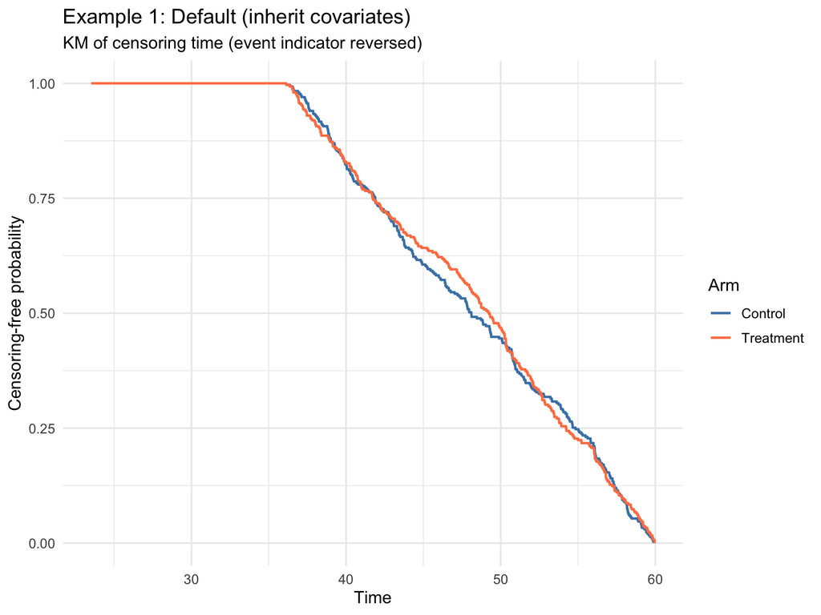

Example 1 — Censoring KM by treatment arm

```r
plot_cens_km(sim1, "Example 1: Default (inherit covariates)")
```

## 7.2 Example 2 — Subset of Censoring Covariates

`continuous_vars_cens` and `factor_vars_cens` supplied explicitly to restrict the censoring model to a smaller subset.

```r
dgm2 <- do.call(generate_aft_dgm_flex, c(common_args, list(
  select_censoring     = TRUE,
  cens_type            = "weibull",
  continuous_vars_cens = c("age", "nodes"),
  factor_vars_cens     = character(0)
)))

sim2 <- simulate_from_dgm(dgm2, n = sim_n, seed = sim_seed,
                          analysis_time = analysis_t)

summarize_cens_example(dgm2, sim2, "Example 2: Subset (age, nodes only)")
```

```
#>
#> === Example 2: Subset (age, nodes only) ===
#> Distribution     : weibull
#> mu  (log-scale)  : 7.4469
#> tau (scale)      : 0.4246
#> Covariate effects: none (intercept-only)
#>
#> Empirical censoring rate (sim, n = 600): 99.7%
```

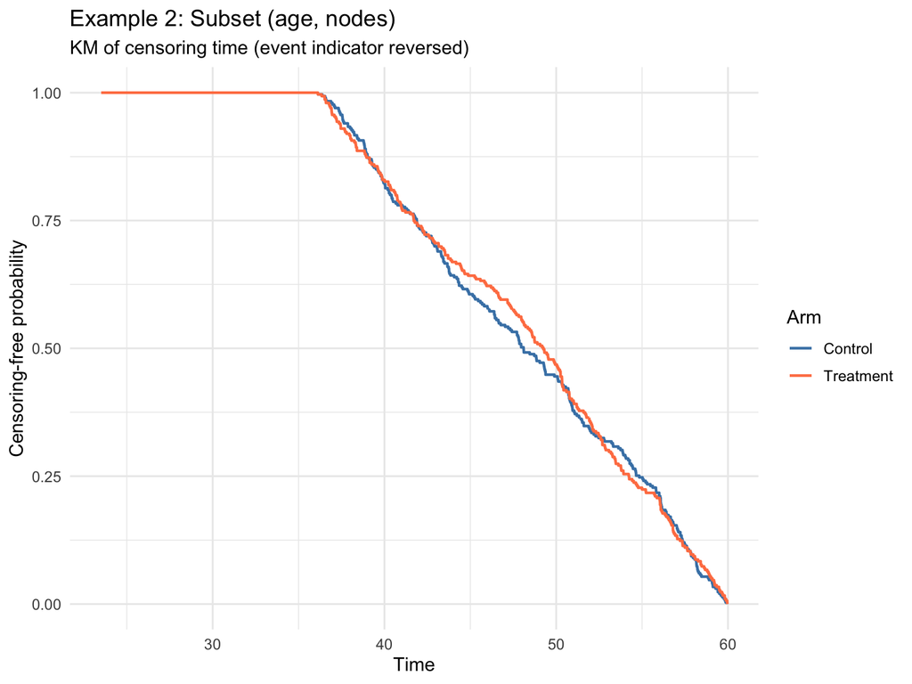

Example 2 — Censoring KM by treatment arm

```r
plot_cens_km(sim2, "Example 2: Subset (age, nodes)")
```

## 7.3 Example 3 — Treatment-Only (No Covariates)

Both `*_cens` arguments set to empty character vectors. The Weibull and lognormal models with treatment only (`Weibull0`, `LogNormal0`) are identical to the with-covariate models in this configuration; AIC will typically pick whichever has lower scale-parameter complexity.

```r
dgm3 <- do.call(generate_aft_dgm_flex, c(common_args, list(
  select_censoring     = TRUE,
  cens_type            = "weibull",
  continuous_vars_cens = character(0),
  factor_vars_cens     = character(0)
)))

sim3 <- simulate_from_dgm(dgm3, n = sim_n, seed = sim_seed,
                          analysis_time = analysis_t)

summarize_cens_example(dgm3, sim3, "Example 3: Treatment-only")
```

```
#>
#> === Example 3: Treatment-only ===
#> Distribution     : weibull
#> mu  (log-scale)  : 7.4177
#> tau (scale)      : 0.4223
#> Covariate effects (gamma):
#>  treat
#> 0.0705
#>
#> Empirical censoring rate (sim, n = 600): 99.7%
```

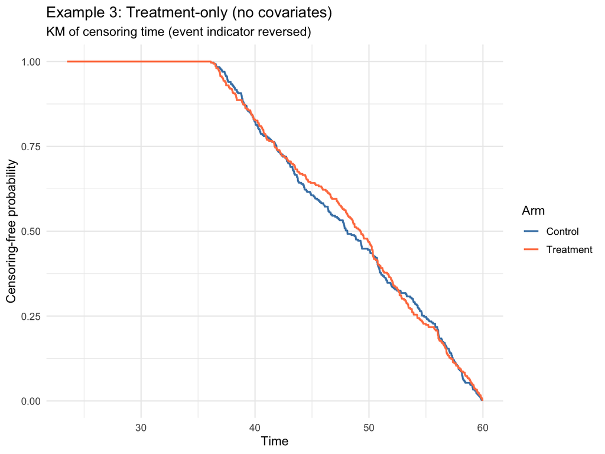

Example 3 — Censoring KM by treatment arm

```r
plot_cens_km(sim3, "Example 3: Treatment-only (no covariates)")
```

## 7.4 Example 4 — Censoring Covariates Different from Outcome

A useful pattern when the analyst has external knowledge about which variables drive loss-to-follow-up vs which drive the outcome. Here the outcome model uses the standard continuous prognostics; the censoring model uses only `meno` (factor) and `grade` (treated as continuous for simplicity).

```r
dgm4 <- do.call(generate_aft_dgm_flex, c(common_args, list(
  select_censoring     = TRUE,
  cens_type            = "weibull",
  continuous_vars_cens = "grade",
  factor_vars_cens     = "meno"
)))

sim4 <- simulate_from_dgm(dgm4, n = sim_n, seed = sim_seed,
                          analysis_time = analysis_t)

summarize_cens_example(dgm4, sim4,
                       "Example 4: Censoring on (meno, grade) only")
```

```
#>
#> === Example 4: Censoring on (meno, grade) only ===
#> Distribution     : weibull
#> mu  (log-scale)  : 7.4469
#> tau (scale)      : 0.4246
#> Covariate effects: none (intercept-only)
#>
#> Empirical censoring rate (sim, n = 600): 99.7%
```

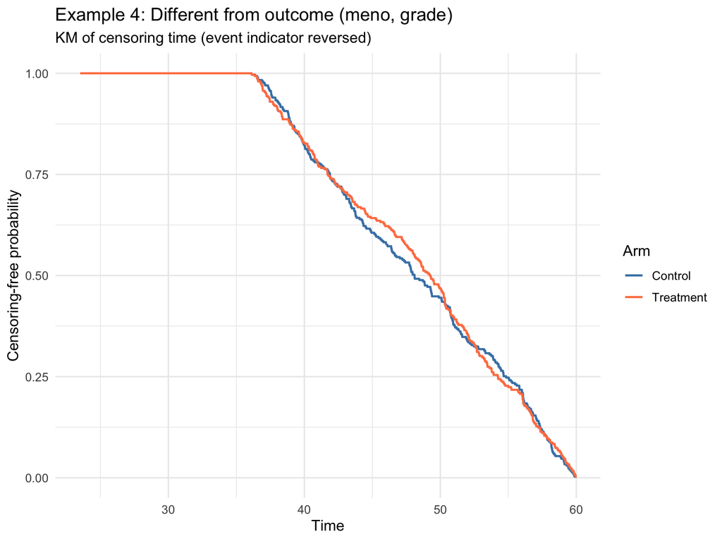

Example 4 — Censoring KM by treatment arm

```r
plot_cens_km(sim4, "Example 4: Different from outcome (meno, grade)")
```

## 7.5 Example 5 — Analytical Weibull

`select_censoring = FALSE` with a user-supplied Weibull. No fitting happens; the censoring distribution is exactly what the caller specifies. Useful for sensitivity analyses where you want to vary the censoring rate without re-fitting.

```r
dgm5 <- do.call(generate_aft_dgm_flex, c(common_args, list(
  select_censoring = FALSE,
  cens_type        = "weibull",
  cens_params      = list(
    mu   = log(80),     # log-scale location: median ~ 80 months
    tau  = 0.7,         # scale parameter
    type = "weibull"
  )
)))

sim5 <- simulate_from_dgm(dgm5, n = sim_n, seed = sim_seed,
                          analysis_time = analysis_t)

summarize_cens_example(dgm5, sim5, "Example 5: Analytical Weibull")
```

```
#>
#> === Example 5: Analytical Weibull ===
#> Distribution     : weibull
#> mu  (log-scale)  : 4.3820
#> tau (scale)      : 0.7000
#> Covariate effects: none (intercept-only)
#>
#> Empirical censoring rate (sim, n = 600): 99.7%
```

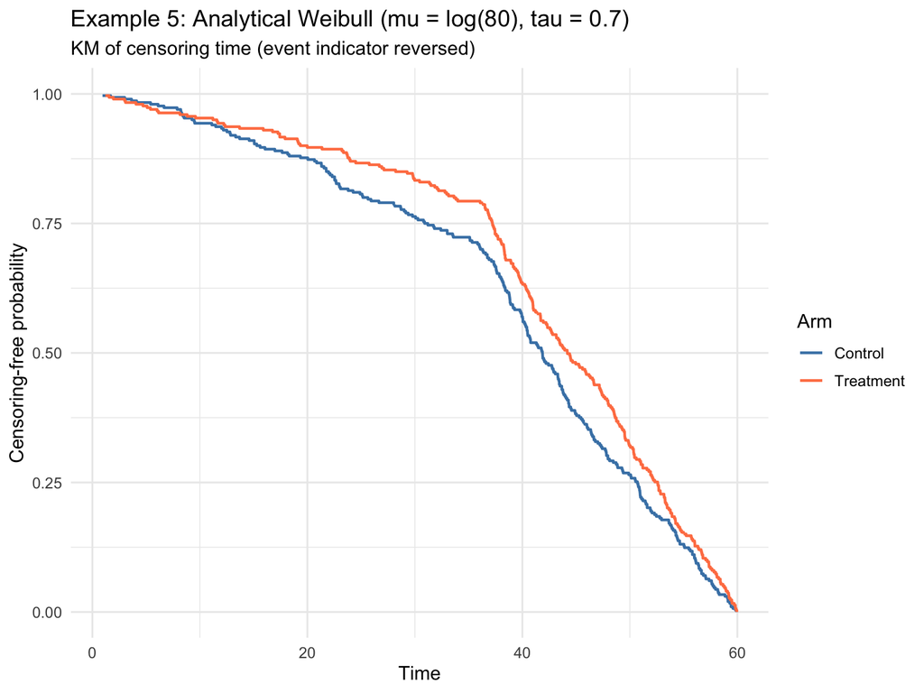

Example 5 — Censoring KM by treatment arm

```r
plot_cens_km(sim5, "Example 5: Analytical Weibull (mu = log(80), tau = 0.7)")
```

## 7.6 Cross-Example Comparison

Side-by-side empirical censoring rates from the five simulated trials:

```r
comparison_df <- data.frame(
  Example      = c("1: Default (inherit)",
                   "2: Subset (age, nodes)",
                   "3: Treatment-only",
                   "4: Different (meno, grade)",
                   "5: Analytical Weibull"),
  Distribution = c(dgm1$model_params$censoring$type,
                   dgm2$model_params$censoring$type,
                   dgm3$model_params$censoring$type,
                   dgm4$model_params$censoring$type,
                   dgm5$model_params$censoring$type),
  N_covariates = c(length(dgm1$model_params$censoring$gamma %||% character(0)),
                   length(dgm2$model_params$censoring$gamma %||% character(0)),
                   length(dgm3$model_params$censoring$gamma %||% character(0)),
                   length(dgm4$model_params$censoring$gamma %||% character(0)),
                   length(dgm5$model_params$censoring$gamma %||% character(0))),
  Cens_rate    = c(1 - mean(sim1$event_sim),
                   1 - mean(sim2$event_sim),
                   1 - mean(sim3$event_sim),
                   1 - mean(sim4$event_sim),
                   1 - mean(sim5$event_sim))
)

gt::gt(comparison_df) |>
  gt::tab_header(
    title    = gt::md("**Censoring Specification — Cross-Example Summary**"),
    subtitle = "Five censoring configurations on the GBSG DGM"
  ) |>
  gt::fmt_percent(columns = "Cens_rate", decimals = 1) |>
  gt::cols_label(
    Distribution = "Selected dist.",
    N_covariates = "# cov. effects",
    Cens_rate    = "Empirical cens. rate"
  )
```

**Censoring Specification — Cross-Example Summary**

Five censoring configurations on the GBSG DGM

| Example | Selected dist. | # cov. effects | Empirical cens. rate |
| --- | --- | --- | --- |
| 1: Default (inherit) | weibull | 0 | 99.7% |
| 2: Subset (age, nodes) | weibull | 0 | 99.7% |
| 3: Treatment-only | weibull | 1 | 99.7% |
| 4: Different (meno, grade) | weibull | 0 | 99.7% |
| 5: Analytical Weibull | weibull | 0 | 99.7% |

# 8 Diagnostics: `check_censoring_dgm()`

For any `aft_dgm_flex` object, `check_censoring_dgm()` compares the observed censoring distribution in the source data against the censoring distribution generated by `simulate_from_dgm()`. Useful for catching time-scale mismatches and other configuration issues.

```r
diag1 <- check_censoring_dgm(sim1, dgm = dgm1, verbose = TRUE)
```

```
#>
#> =========================================================
#>   Censoring Diagnostic: DGM Reference vs Simulated
#> =========================================================
#>   DGM censoring type  : weibull
#>   DGM mu_cens         : 7.4469  [exp = 1714.51 time units]
#>   DGM tau_cens        : 0.4246
#>   Reference n (super) : 5000
#>   Simulated n         : 600
#>
#> --- 1. Censoring Rates ---
#>    Group Ref_rate Sim_rate     Diff
#>  Overall    55.3%    99.7% +44.3 pp
#>    Arm 0    51.7%    99.7% +48.0 pp
#>    Arm 1    61.8%    99.7% +37.9 pp
#>
#> --- 2. Censoring-Time Quantiles (censored subjects only) ---
#>     Ref: y[event == 0]  |  Sim: c_time[event_sim == 0]
#>  Quantile  Ref   Sim Ratio
#>       25%  858 41.82 0.049
#>       50% 1432 48.74 0.034
#>       75% 1858 54.58 0.029
#>       90% 2161 57.82 0.027
#>
#> --- 3. KM Median Censoring Time (reversed event indicator) ---
#>    Group Ref_median Sim_median Ratio
#>  Overall       1645   48.74976 0.030
#>    Arm 0       1560   48.09822 0.031
#>    Arm 1       1756   49.25023 0.028
#>
#> --- 4. Implied Time-Scale Check ---
#>   exp(params$mu)          = 1852.33  [median outcome time, DGM scale]
#>   exp(params$censoring$mu)= 1714.51  [median censoring time, DGM scale]
#>   If these values are implausibly large relative to your
#>   analysis_time, the DGM was likely built on a different time
#>   scale (e.g. days vs months).
#>
#> [WARNING] Potential discrepancies detected:
#>   * Censoring rate: ref = 55.3%, sim = 99.7%  [|diff| = 44.3 pp > tol 10.0 pp]
#>   * KM median censoring: ref = 1645.00, sim = 48.75  [ratio = 0.03, tol = 1.25]
#>
#> Common causes:
#>   1. Time-scale mismatch: verify exp(dgm$model_params$mu) is
#>      plausible relative to analysis_time.
#>   2. cens_adjust shifting censoring substantially from fitted model.
#>   3. Short analysis_time / time_eos making admin censoring dominant.
#> =========================================================
```

```r
cat("\nFlags raised:\n")
```

```
#>
#> Flags raised:
```

```r
if (length(diag1$flags) > 0) {
  cat(paste("  -", diag1$flags), sep = "\n")
} else {
  cat("  (none)\n")
}
```

```
#>   - Censoring rate: ref = 55.3%, sim = 99.7%  [|diff| = 44.3 pp > tol 10.0 pp]
#>   - KM median censoring: ref = 1645.00, sim = 48.75  [ratio = 0.03, tol = 1.25]
```

The diagnostic compares overall and per-arm censoring rates and KM medians, flagging discrepancies above the configured tolerances (default 10 percentage points for rates, 25% relative for medians).

# 9 Limitations

A few items worth being aware of when using the censoring API:

- **AIC always arbitrates.** Even if you supply `continuous_vars_cens` / `factor_vars_cens`, the intercept-only fits (`Weibull0` / `LogNormal0`) compete in the AIC comparison. The covariate-laden Weibull is *available* but not *forced*; if AIC prefers an intercept-only fit, the covariate effects will be dropped and the resulting `lin_pred_cens_*` values will be zero. There is currently no flag to force covariate inclusion.
- **Distribution choice is constrained to two families.** The four candidate models cover Weibull and lognormal only. Other AFT-family distributions (log-logistic, generalized gamma) are not included in the comparison.
- **Covariate effects on censoring are mean-only.** The fitted censoring scale parameter is a single \(\tau_c\); covariates affect the location \(\mu_c + \gamma_c’ X\) but not the scale.
- **Path A is intercept-only by structural choice.** When `select_censoring = FALSE`, there is no API for supplying covariate coefficients analytically — `lin_pred_cens_*` are always zero in this path.

# 10 References

León LF, Jemielita T, Guo Z, Marceau West R, Anderson KM (2024). “Exploratory subgroup identification in the heterogeneous Cox model: A relatively simple procedure.” *Statistics in Medicine*. DOI: 10.1002/sim.10163

Kalbfleisch, J.D. and Prentice, R.L. (2002). *The Statistical Analysis of Failure Time Data* (2nd ed.). Wiley.

Schumacher M, Bastert G, Bojar H, et al. (1994). Randomized 2 × 2 trial evaluating hormonal treatment and the duration of chemotherapy in node-positive breast cancer patients. German Breast Cancer Study Group. *J Clin Oncol*. 12(10):2086-93.